# **Final Project - Unit 2: Data Understanding**

### **Identifying & Addressing Outliers for Handling Missing Data**

**20) Before we can peform any imputation, let's make sure we don't have outliers first. Note down any variables we will be imputing that also containing outliers below...**

- avg_air_quality
- price

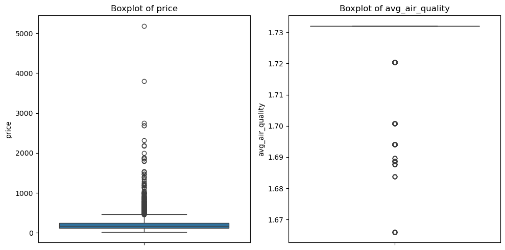

```python
# replace with code to check variables for outliers (via a boxplot)
outlier_vars = ["price", "avg_air_quality"]

# Create boxplots for each variable
plt.figure(figsize=(10, 5))
for i, var in enumerate(outlier_vars, 1):
    plt.subplot(1, len(outlier_vars), i)
    sns.boxplot(y=df2[var])
    plt.title(f'Boxplot of {var}')
plt.tight_layout()
plt.show()
```

**21) How can you address these outliers before proceeding with handling your missing data values?**

just use median

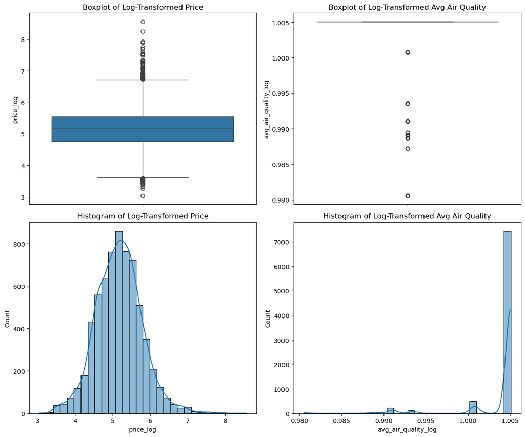

```python
# replace with code to log transform outliers for first variable
# replace with code to recheck for outliers via a boxplot
df2["price_log"] = np.log1p(df2["price"])
df2["avg_air_quality_log"] = np.log1p(df2["avg_air_quality"])

# Create a 2x2 grid for subplots
fig, axes = plt.subplots(2, 2, figsize=(12, 10))

# Boxplots
sns.boxplot(y=df2["price_log"], ax=axes[0, 0])
axes[0, 0].set_title("Boxplot of Log-Transformed Price")

sns.boxplot(y=df2["avg_air_quality_log"], ax=axes[0, 1])
axes[0, 1].set_title("Boxplot of Log-Transformed Avg Air Quality")

# Histograms
sns.histplot(df2["price_log"], bins=30, kde=True, ax=axes[1, 0])
axes[1, 0].set_title("Histogram of Log-Transformed Price")

sns.histplot(df2["avg_air_quality_log"], bins=30, kde=True, ax=axes[1, 1])
axes[1, 1].set_title("Histogram of Log-Transformed Avg Air Quality")

plt.tight_layout()
plt.show()
```

**22) Did transforming the variable change the distribution? Is it roughly normal (yes or no), and what does that mean in terms of performing a simple imputation?**

Yes - we can't check if its roughly normal with a box plot, that is flawed, we have done a histogram as well

**23) Perform Imputation (simple or multiple) for the first variable below:**

```python
# replace with code to remove or impute first variable observations with missing data
df2["price"] = df2.groupby("neighbourhood_cleansed")["price"].transform(lambda x: x.fillna(x.median()))
```

**24) Perform Imputation (simple or multiple) for the second variable below:**

```python
# repeat with additional variables, consider what type of imputation is appropriate given the data distribution
# AND patterns of missingness
df2["avg_air_quality"] = df2.groupby("neighbourhood_cleansed")["avg_air_quality"].transform(lambda x: x.fillna(x.median()))
```

**25) Are there any variables that could potentially be MNAR? When data are MNAR, what can be done about it?**

air quality potentially

### **Additional Outliers**

**Identify any remaining outliers by using a grid of boxplots. Then, choose two variables with outliers to either transform or discretize. For each variable, explain what step you took and whether the step was successful in addressing the presence (of at least extreme) outliers.**

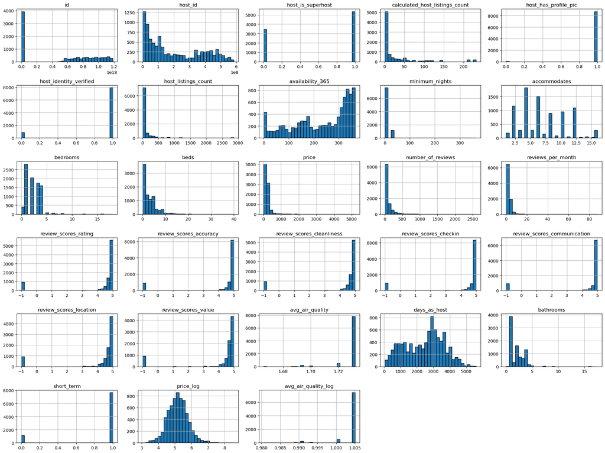

```python
df2.hist(figsize=(20, 15), bins=30, layout=(6, 5), edgecolor="black")

plt.tight_layout()
plt.show()
```

**26) List the two variables you identified as having outliers that you want to transform/discretize here:**

- review_scores_location
- beds

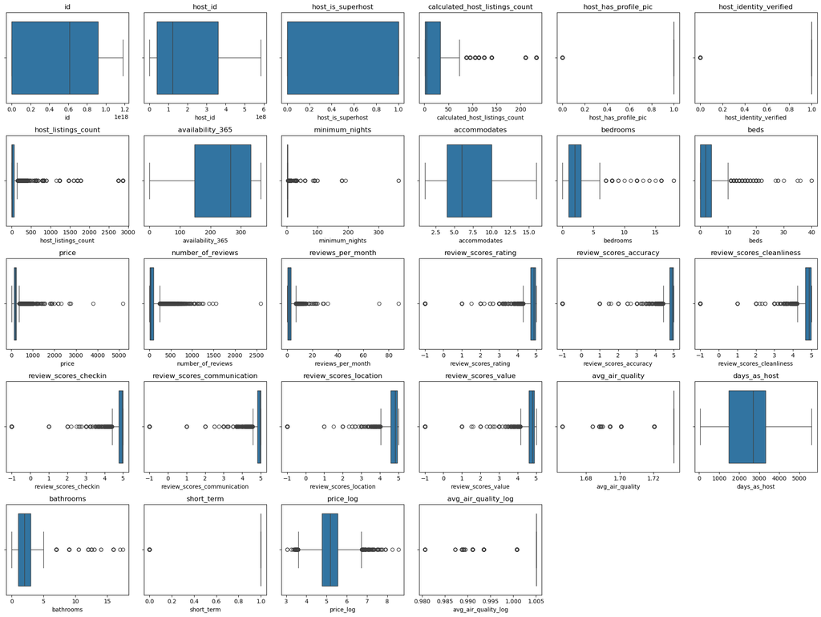

```python
# this code creates a grid of boxplots for the int and float variables

# Select numerical columns
numerical_cols = df2.select_dtypes(include=['int64', 'float64']).columns

plt.figure(figsize=(20, 15))
for i, col in enumerate(numerical_cols, 1):
    plt.subplot(5, 6, i)
    sns.boxplot(x=df2[col])
    plt.title(col)

plt.tight_layout()
plt.show()
```

**27) Perform a transformation/discretization on your first selected variable below, explain what step you took and whether it has reduced/fixed your outliers for this variable (hint: you can check with a boxplot or histogram to confirm).**

```python
# replace with code needed for addressing variable 1 with outliers
from scipy.stats import zscore
from scipy.stats.mstats import winsorize

df2["review_scores_location_z"] = zscore(df2["review_scores_location"])
df2["beds_winsorized"] = winsorize(df2["beds"], limits=[0.05, 0.05])
```

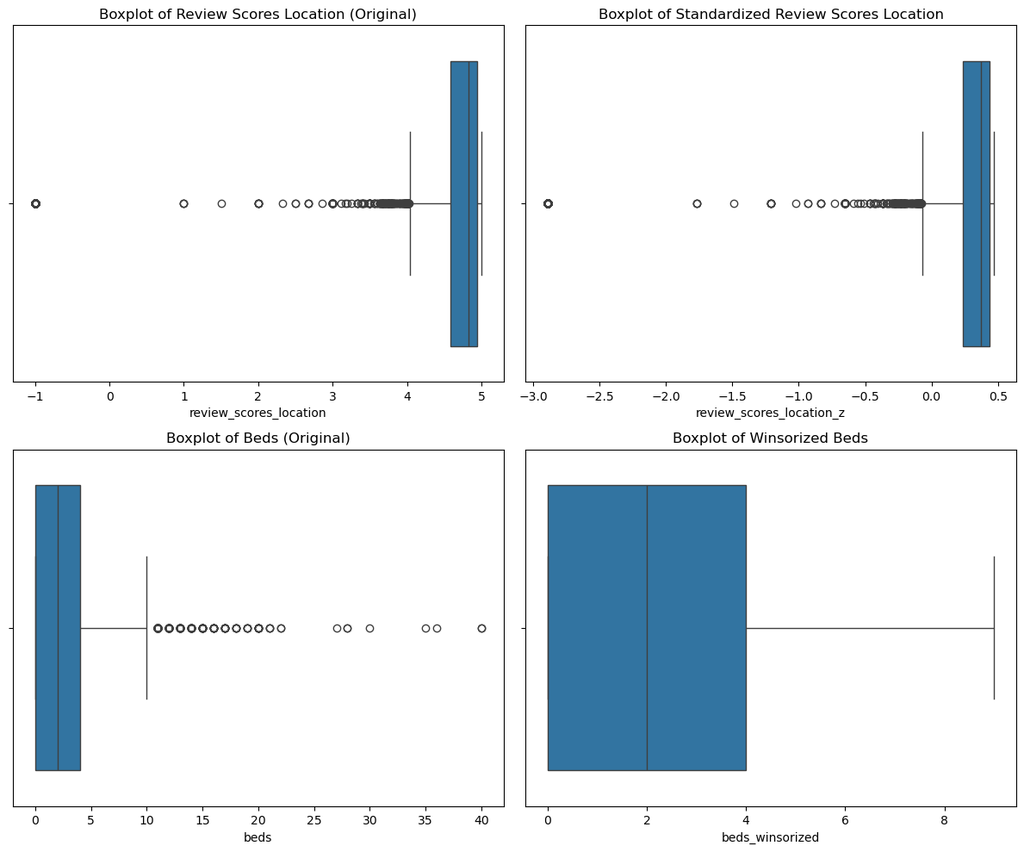

```python
fig, axes = plt.subplots(2, 2, figsize=(12, 10))

# Boxplots
sns.boxplot(x=df2["review_scores_location"], ax=axes[0, 0])
axes[0, 0].set_title("Boxplot of Review Scores Location (Original)")

sns.boxplot(x=df2["review_scores_location_z"], ax=axes[0, 1])
axes[0, 1].set_title("Boxplot of Standardized Review Scores Location")

sns.boxplot(x=df2["beds"], ax=axes[1, 0])
axes[1, 0].set_title("Boxplot of Beds (Original)")

sns.boxplot(x=df2["beds_winsorized"], ax=axes[1, 1])
axes[1, 1].set_title("Boxplot of Winsorized Beds")

plt.tight_layout()
plt.show()
```

**Explanation of steps taken and whether the steps worked**: We used z-score standardization to transform review_scores_location, which allows us to identify outliers more easily by converting the values into standard deviations from the mean. However, we did not remove values—we only transformed them to make outliers more detectable.

For beds, we applied Winsorization, which caps extreme outliers at the 5th and 95th percentiles rather than removing them. This ensures that extreme values do not distort the dataset while maintaining a reasonable range.

Now, the data is in a better range, reducing the influence of extreme values while preserving the overall distribution.

**28) Perform a transformation or discretization on your second selected variable. Explain what step you took and whether it has reduced/fixed your outliers for this variable (hint: you can check with a boxplot or histogram to confirm).**

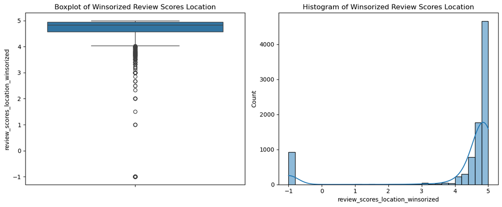

```python
# replace with code needed for addressing variable 2 with outliers
df2["review_scores_location_winsorized"] = winsorize(df2["review_scores_location"], limits=[0.05, 0.05])

# Plot boxplot and histogram to confirm outlier adjustment
fig, axes = plt.subplots(1, 2, figsize=(12, 5))

sns.boxplot(y=df2["review_scores_location_winsorized"], ax=axes[0])
axes[0].set_title("Boxplot of Winsorized Review Scores Location")

sns.histplot(df2["review_scores_location_winsorized"], bins=30, kde=True, ax=axes[1])
axes[1].set_title("Histogram of Winsorized Review Scores Location")

plt.tight_layout()
plt.show()
```

### **29) Guiding Next Steps**

**You are about to pass off this data for its next steps in modeling. 1) What should the data team know about problems you encountered in the dataset, and how you handled these issues? 2) Are there any unresolved issues they should be aware of? 3) Finally, provide a brief explanation from Parts 1 and 2 regarding interesting observations or hypotheses you noted, that they should continue to explore as they begin modeling.**

- 1. Reviews can be null
- 2. There are outliers that make sense, such as properties that are really large.
- 3. Seeing what size properties are most common could be extremely important to look into.

```python
# export your finalized dataset and turn in with your submission!
df2.to_csv("cleansed.csv")
```